- Describe your work and results clearly.
- Assume the reader has an introductory course level understanding of writing and reading R code as well as statistical methods
- Assume the reader has no previous knowledge of your data or the more advanced methods you are using

# Data analysis for IODS week 2

The data has been read into the system and it has been collected 3.12.2014 – 10.1.2015. The original results were from an international survey of Approaches to Learning. The following data includes variables as described in [here](https://www.slideshare.net/kimmovehkalahti/the-relationship-between-learning-approaches-and-students-achievements-in-an-introductory-statistics-course-in-finland). The summary variables (such as *deep_adj*) answer to questions like how deeply the individual is trying to learn and how organized is his/her studying.

Next, I will briefly examine the data set’s dimensions and structure.

```r
# First six rows of the data set
head(students2014)
```

```
##   gender Age Attitude Points Deep_adj Surf_adj Stra_adj
## 1      F  53       37     25 3.583333 2.583333    3.375
## 2      M  55       31     12 2.916667 3.166667    2.750
## 3      F  49       25     24 3.500000 2.250000    3.625
## 4      M  53       35     10 3.500000 2.250000    3.125
## 5      M  49       37     22 3.666667 2.833333    3.625
## 6      F  38       38     21 4.750000 2.416667    3.625
```

```r
# The dimensions
dim(students2014)
```

```
## [1] 166   7
```

```r
# Type of variables
str(students2014)
```

```
## 'data.frame':    166 obs. of  7 variables:
##  $ gender  : Factor w/ 2 levels "F","M": 1 2 1 2 2 1 2 1 2 1 ...
##  $ Age     : int  53 55 49 53 49 38 50 37 37 42 ...
##  $ Attitude: int  37 31 25 35 37 38 35 29 38 21 ...
##  $ Points  : int  25 12 24 10 22 21 21 31 24 26 ...
##  $ Deep_adj: num  3.58 2.92 3.5 3.5 3.67 ...
##  $ Surf_adj: num  2.58 3.17 2.25 2.25 2.83 ...
##  $ Stra_adj: num  3.38 2.75 3.62 3.12 3.62 ...
```

```r
# Summaríes of the variables included in the data
summary(students2014)
```

```
##  gender       Age           Attitude         Points         Deep_adj
##  F:110   Min.   :17.00   Min.   :14.00   Min.   : 7.00   Min.   :1.583
##  M: 56   1st Qu.:21.00   1st Qu.:26.00   1st Qu.:19.00   1st Qu.:3.333
##          Median :22.00   Median :32.00   Median :23.00   Median :3.667
##          Mean   :25.51   Mean   :31.43   Mean   :22.72   Mean   :3.680
##          3rd Qu.:27.00   3rd Qu.:37.00   3rd Qu.:27.75   3rd Qu.:4.083
##          Max.   :55.00   Max.   :50.00   Max.   :33.00   Max.   :4.917
##     Surf_adj        Stra_adj
##  Min.   :1.583   Min.   :1.250
##  1st Qu.:2.417   1st Qu.:2.625
##  Median :2.833   Median :3.188
##  Mean   :2.787   Mean   :3.121
##  3rd Qu.:3.167   3rd Qu.:3.625
##  Max.   :4.333   Max.   :5.000
```

So, from the above we can conclude that the data has 166 observations and each observation consists of 7 variables as the data frame has 166 rows and 7 columns. The data consists of mainly numerical information on the respondents

- gender (coded as M for males and F for females)
- age
- global attitude toward statistics
- points in the final exam
- measures for
  - deep learning
  - how surfaced is the learning (emphasis in learning single, separate pieces of information)
  - strategic learning.

The sum variables (Points, Deep_adj, Surf_adj, Stra_adj) were created as instructed by [Kimmo](http://www.helsinki.fi/~kvehkala/JYTmooc/JYTOPKYS2-meta.txt).

## Graphical overview

First, we will construct pairwise plots of each variable and draw bigger histograms to see the variables’ distribution.

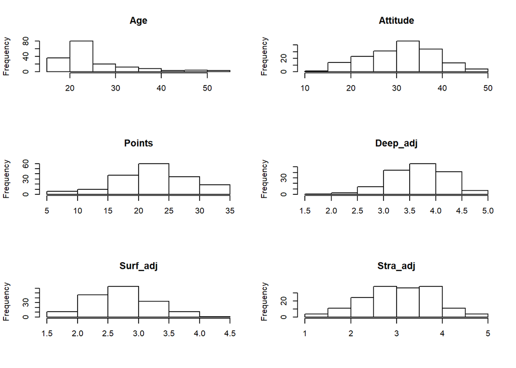

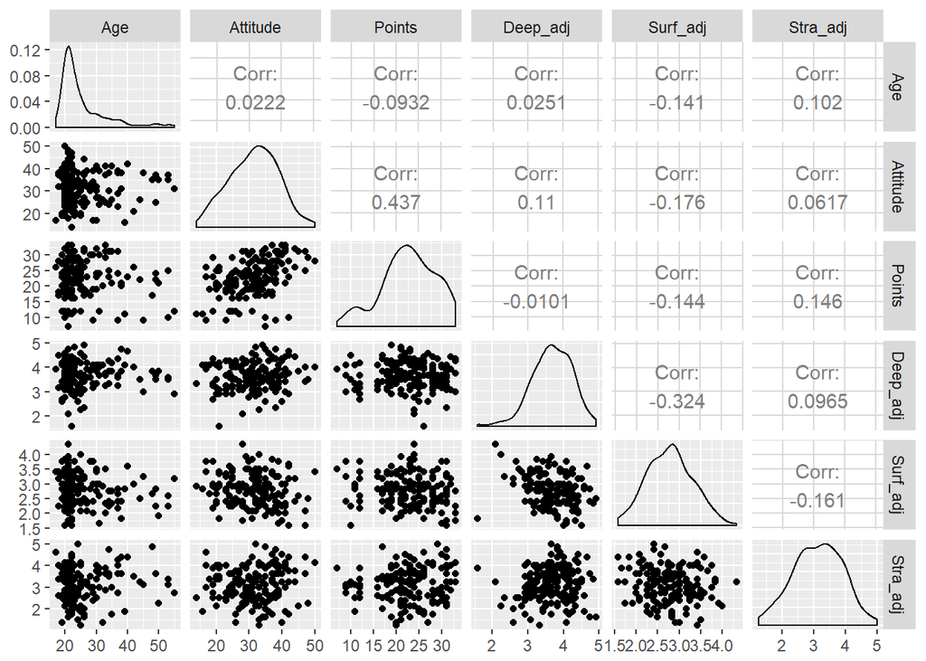

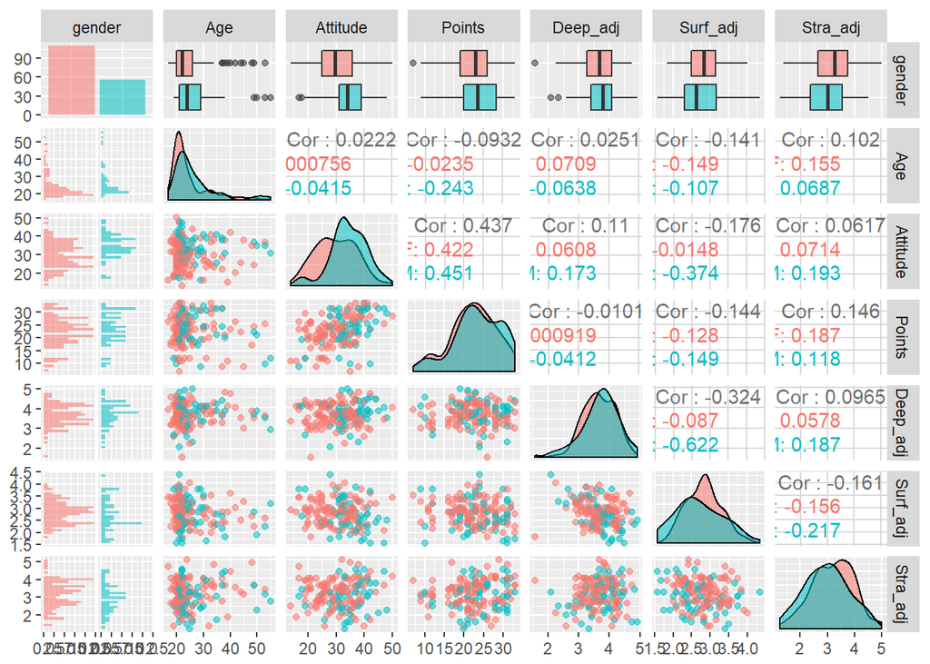

From the lower matrix it is also visible that males seem to have a bit better attitude toward statistics and that women tend to be more methodological with their approach to studying.

## Regression

Let’s perform a linear regression where we assume that there is a linear dependency between the dependent variable and the explanatory variables. Linear model can be expressed as
$$y = \alpha + \beta_1 x_1 + \beta_2 x_2 + \beta_3 x_3 + \epsilon$$
where $x_1, x_2, x_3$ are the values of the explanatory variables and $y$ the value of the dependent variable. Epsilon is considered as the error parameter or *residuals*, which should be normally distributed, $\epsilon \sim N(0,\sigma^2)$. The residuals are examined via the diagnostic plots.

```
##
## Call:
## lm(formula = Points ~ Attitude + Age + Stra_adj, data = students2014)
##
## Residuals:
##      Min       1Q   Median       3Q      Max
## -18.1149  -3.2003   0.3303   3.4129  10.7599
##
## Coefficients:
##             Estimate Std. Error t value Pr(>|t|)
## (Intercept) 10.89543    2.64834   4.114 6.17e-05 ***
## Attitude     0.34808    0.05622   6.191 4.72e-09 ***
## Age         -0.08822    0.05302  -1.664   0.0981 .
## Stra_adj     1.00371    0.53434   1.878   0.0621 .
## ---
## Signif. codes:  0 '***' 0.001 '**' 0.01 '*' 0.05 '.' 0.1 ' ' 1
##
## Residual standard error: 5.26 on 162 degrees of freedom
## Multiple R-squared:  0.2182, Adjusted R-squared:  0.2037
## F-statistic: 15.07 on 3 and 162 DF,  p-value: 1.07e-08
```

From the summary it is visible that only attitude raises – or affects – performance in the final exam on 5 per cent significance level. For every attitude point gained it is estimated that an average of 0.35 exam points is achieved. We also notice from the output that age has the least significant effect on our model so we remove it from the model.

```r
# Remove variable age by update() function
model <- update(model, formula. = .~. - Age)

summary(model)
```

```
##
## Call:
## lm(formula = Points ~ Attitude + Stra_adj, data = students2014)
##
## Residuals:
##      Min       1Q   Median       3Q      Max
## -17.6436  -3.3113   0.5575   3.7928  10.9295
##
## Coefficients:
##             Estimate Std. Error t value Pr(>|t|)
## (Intercept)  8.97290    2.39591   3.745  0.00025 ***
## Attitude     0.34658    0.05652   6.132 6.31e-09 ***
## Stra_adj     0.91365    0.53447   1.709  0.08927 .
## ---
## Signif. codes:  0 '***' 0.001 '**' 0.01 '*' 0.05 '.' 0.1 ' ' 1
##
## Residual standard error: 5.289 on 163 degrees of freedom
## Multiple R-squared:  0.2048, Adjusted R-squared:  0.1951
## F-statistic: 20.99 on 2 and 163 DF,  p-value: 7.734e-09
```

*Using a summary of your fitted model, explain the relationship between the chosen explanatory variables and the target variable (interpret the model parameters). Explain and interpret the multiple R squared of the model.*

From the summary of the model we see that one could get approximately 9 points from the final exam with zero attitude and no strategy in learning. We can conclude that attitude has a very significant effect, which stays in the same level as in the previous model. The p-value given tests against the null hypothesis that the coefficient of the variable is zero (alpha, beta or gamma in the equation above). And as is seen, for every 1 point of attitude the score on the final exam rises approximately 0.35 points.

The R-squared of the output tells us how well our model explains the variability of the dependent variable. In this case, our model explains roughly 20.5 per cent of the variability, which is quite bad. According to some sources the $R^2$ should be around 0.40 – 0.60.

## Diagnostics

Let’s produce the diagnostic plots:

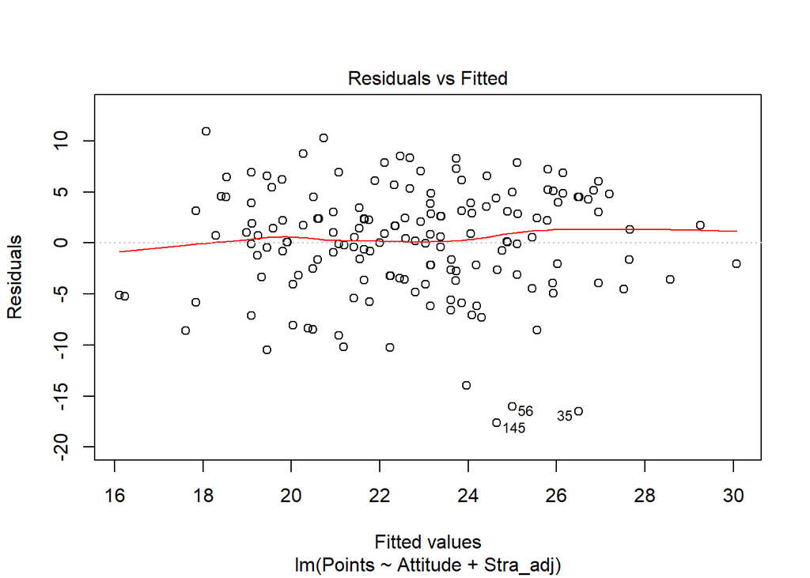

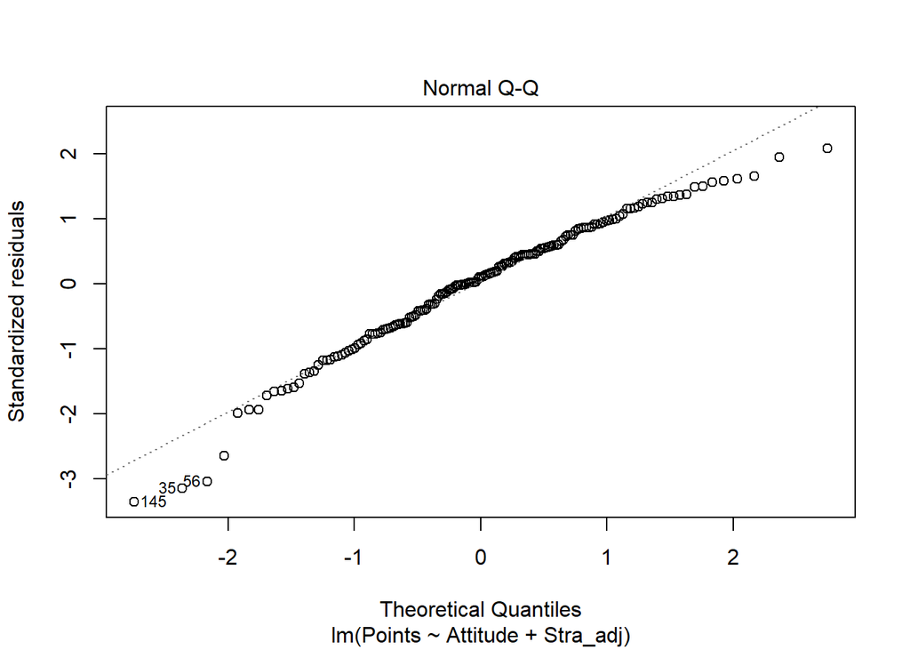

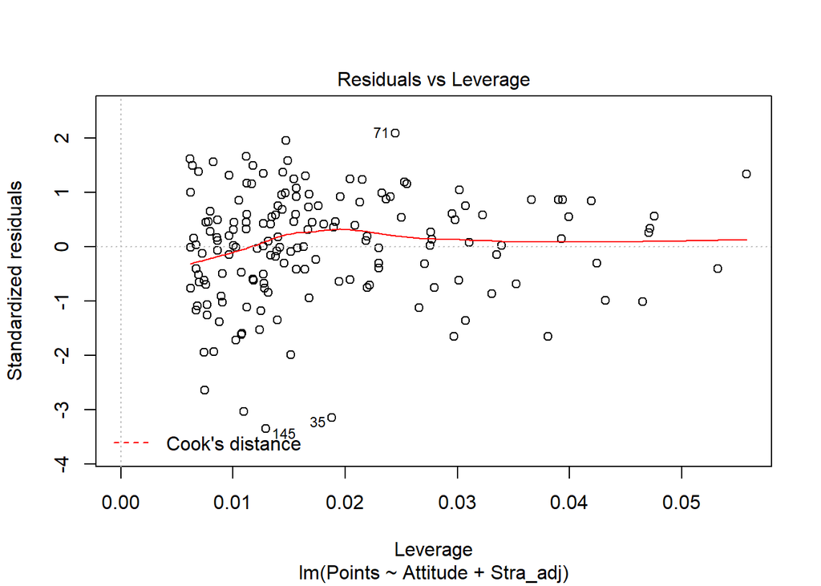